# Effect of Content on IMDB Ratings

Nathan D, Peyton R, Daoming L

2021-12-02

### Section 1 - Introduction:

Our research question is: How is imdb rating affected by different variables including duration of the film / series, type (film or series), amount of nudity, and certificate rating. These variables will be described below.

The data itself is available on [Kaggle](https://www.kaggle.com/mazenramadan/imdb-most-popular-films-and-series). The specific data in the data frame is from imdb.com, where users are able to rate various films or series on their website based on how good they thought it was. The data was collected by the imdb website as users who have watched a series / film decide on an imdb rating they will give these various films or series from 1 to 10, 10 being the best and 1 the worst. These ratings are averaged to create one single continuous numerical mean imdb rating for each film / series, which is what the variable, Rate, means in our dataset. Imdb ratings are useful to judge how good each one of these films or series is, the higher the better. Our dataset includes about 6000 of the most popular tv series and movies.

The variables in the data set other than Rate, the imdb rating itself, could affect the imdb rating of these films or series. These variables include date (Air date), Genre, Duration, Type(series or film), Certificate (Rated R, PG-13, etc.), Episodes, Nudity(Amount of nudity), Violence(Amount of violence), Profanity(Amount of profanity), and Alcohol(Amount of alcohol). The other variable is Name, which is the name of the film / series, but that wouldn’t be used to assess imdb rating as an explanatory variable as there is one unique name for each row. All of these other variables are details about the specific films / series that may affect imdb ratings, what we will be trying to figure out.

### Section 2 - Data analysis plan:

The outcome, or dependent variable, in this case is the Rate variable (numeric, continuous), representing the imdb rating for certain series / films which is measured by the mean of all the ratings users gave. The predictor variables we will use are nudity, type, certificate, and duration. Nudity(categorical, 4 levels) is measured by and represents how much nudity is in the film. Type(categorical, 2 levels) represents and is measured by the type of the production, series or film. Certificate(categorical) is measured by and represents the certificate rating of the film / series (R, PG-13, PG, TV-MA, TV-14, etc.). Finally the duration(numerical) describes and is measured by the duration of the film or series in minutes. We may plan to use more variables, but these are the 4 we plan on using at the moment.

One challenge we could face would be small sample size for specific categories. There aren’t, for example, many films / series with a certificate of TV-Y in the Certificate field, which is why we are filtering for only the most relevant categories with larger samples. One more challenge we could face is that there are some variables for specific films / series that have “no rate” in some categories, like nudity, meaning there was no specific rating for that variable. We will have to remove those for each variable that has “no rate” anywhere. Another challenge we may face is that this is not a random sample but the most popular shows and movies, so there may be some bias towards higher or lower ratings. However we are not too worried about this as this may affect our baseline, it shouldn’t impact the variation in the rating when factoring the other variables.

The first step for data analysis is to remove any films/series without imdb ratings. After that, we can calculate some summary statistics for Rate, imdb rating. We learn from this data what some key variables for imdb ratings are, like median and mean. These summary statistics can later be used as a baseline to analyze how much different the statistics are when calculating the same summary statistics for specific variables, like mean imdb ratings for mild nudity, and analyze their differences. We could see if the statistics are higher, lower, or about the same as our baseline without any filters or variables used.

```
## # A tibble: 1 × 4
##   median_imdb mean_imdb sd_imdb iqr_imdb
##         <dbl>     <dbl>   <dbl>    <dbl>
## 1           7      6.88    1.08      1.4
```

We can also make a histogram to view the distribution and find the shape, spread, and center of imdb ratings. We learn from this visualization what the shape, center, and spread of imdb ratings look like. We can later compare this histogram to other histograms represented by specific variables, like a imdb rating for mild violence histogram, to analyze how much the graph is differentiated for specific variables. We can compare graphs and could see if some histograms have any skew or if they are similar to this created graph to show little imdb rating difference.

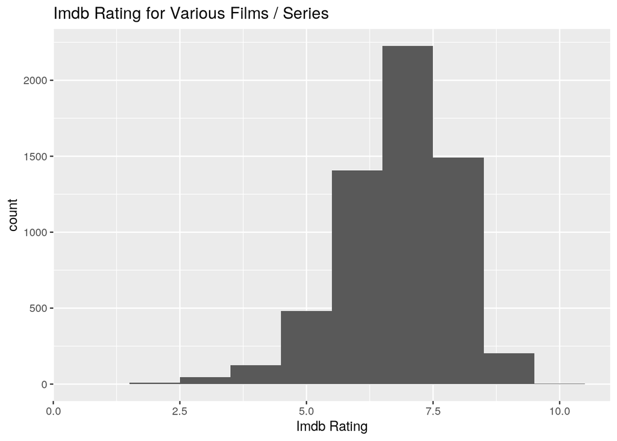

We can start our data analysis with variables by using type. We can see which type, series or film, we expect to have a higher imdb rating or if there is no difference using a side-by-side box plot. With this box plot, we can use the results to learn about the data using the median. The medians we observe tell us that we expect series to have a higher imdb rating than films as the median imdb rating is greater for series. Boxplots like this can help analyze differences between categories within variables like type.

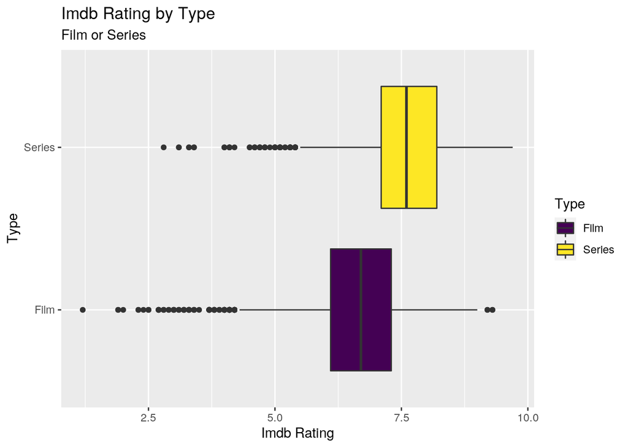

One statistical method we could use would be a confidence interval. We could use a confidence interval to compare different categories within variables, comparing film to series in “type” for example, in order to figure out the difference in the mean imdb rating for the categories. We could use the results, upper and lower quartile, to figure out if imdb rating is affected by these variables using a confidence interval. Another method we could use is making a side-by-side box plot, like above, to visualize the difference within each category in every variable. We could use the results, median and quartiles, to figure out which category affects imdb rating the most by having a much higher or lower rating or if imdb rating doesn’t have much change for the variable. One more method we could use would be a linear regression model. We could use this model to analyze the slope and intercept of imdb ratings for specific variables. We can use the results, slope and intercept, to predict imdb ratings using these equations and see how these equations compare to each other for separate variables to figure out which usually has the highest imdb rating.

### Section 3 - Data & Codebook

Codebook:

| Variable Name | Description |
| --- | --- |
| Name | Name of film or series |
| Date | Date of creation / airing for film or series |
| Rate | Imdb rating for film / series |
| Votes | Number of votes for imdb rating recieved (Scale of 1-10) |
| Genre | Genre of film or series (Drama, Comedy, etc.) |
| Duration | Duration of film or series (min) |
| Type | Whether it is a film or series |
| Certificate | Rating of film or series (R, PG-13, etc.) |
| Episodes | Number of episodes |
| Nudity | Amount of nudity (No Rate, None, Mild, Moderate, Severe) |
| Violence | Amout of violence (No Rate, None, Mild, Moderate, Severe) |
| Profanity | Amount of profanity (No Rate, None, Mild, Moderate, Severe) |
| Alcohol | Amount of alcohol (No Rate, None, Mild, Moderate, Severe) |
| Frightening | How frightening the film or series was (No Rate, None, Mild, Moderate, Severe) |

This data set has 14 columns (variables) and 5993 rows (observations) after the filter to remove those with no imdb ratings.

Below I have a glimpse of our filtered data:

```
## Rows: 5,993
## Columns: 14
## $ Name        <chr> "No Time to Die", "The Guilty", "The Many Saints of Newark…
## $ Date        <dbl> 2021, 2021, 2021, 2021, 2021, 2021, 2021, 2021, 2021, 2021…
## $ Rate        <dbl> 7.6, 6.3, 6.4, 6.4, 8.3, 8.8, 7.3, 7.6, 8.3, 8.2, 7.9, 7.4…
## $ Votes       <chr> "107,163", "64,375", "27,145", "30,443", "84,636", "117,56…
## $ Genre       <chr> "Action, Adventure, Thriller", "Crime, Drama, Thriller", "…
## $ Duration    <chr> "163", "90", "120", "97", "155", "30", "115", "None", "45"…
## $ Type        <chr> "Film", "Film", "Film", "Film", "Film", "Series", "Film", …
## $ Certificate <chr> "PG-13", "R", "R", "PG-13", "PG-13", "TV-MA", "PG-13", "TV…
## $ Episodes    <chr> "-", "-", "-", "-", "-", "23", "-", "18", "25", "177", "6"…
## $ Nudity      <chr> "Mild", "None", "Moderate", "None", "None", "Mild", "Mild"…
## $ Violence    <chr> "Moderate", "None", "Severe", "Moderate", "Moderate", "Non…
## $ Profanity   <chr> "Mild", "Severe", "Severe", "Moderate", "None", "Severe", …
## $ Alcohol     <chr> "Mild", "None", "Moderate", "Mild", "Mild", "Mild", "None"…
## $ Frightening <chr> "Moderate", "Moderate", "Moderate", "Moderate", "Moderate"…
```